# Project 1

Skyler Moomey

2020-09-28

Abstract

Four predictors of software defects were created by researchers at West Virginia University. Each measurement was given an upper bound. If any predictor was measured to be higher than its upper bound, that piece of software was predicted to have an error. All such measurements were recorded in SWDEFECTS.csv, along with their true defective status. This study finds that the predictors of defects tended to be quite accurate, but also gave many false alarms.

# 1 Introduction to the Data

## 1.1 Data and Variables

In order to predict the reliability of large sets of software, engineers and computer scientists developed several algorithms. These four algorithms measure four different attributes of a given file, namely: lines of code, cyclomatic complexity, essential complexity, and design complexity. If these attributes exceed a given upper bound, different for each measurement, the algorithm predicts that file to have a defect. This data is stored in SWDEFECTS.csv.

## 1.2 Summary Table

Defect Predictions v Actual

```r
#all data in table
swdefects.tab <- read.csv("SWDEFECTS.csv")


#total two-way summary table
predictions <- with(swdefects.tab, (predict.vg.10 == "yes") | (predict.evg.14.5 == "yes")
                                      | (predict.ivg.9.2 == "yes") | (predict.loc.50 == "yes"))

#takes a 4x4 table and a grand total and creates a two way summary table
twowaysum <- function(tab, total)
{
  mat = matrix(c(tab[1, 1], tab[1, 2], I(tab[1,1] + tab[1,2])
                 ,tab[2, 1], tab[2,2], I(tab[2,1] + tab[2, 2])
                 , I(tab[1,1] + tab[2,1]), I(tab[1,2] + tab[2,2]), total)
               , ncol=3,byrow=TRUE)
  colnames(mat) = c("No Defect", "Defect", "Row Totals")
  rownames(mat) = c("Not Predicted", "Predicted", "Column Totals")
  mat
}

totals.tab <- table(predictions, swdefects.tab$defect)

twowaysum(totals.tab, nrow(swdefects.tab))
```

```
##               No Defect Defect Row Totals
## Not Predicted       390     29        419
## Predicted            59     20         79
## Column Totals       449     49        498
```

## 1.3 Formulae

1. Accuracy: $P($Algorithm is correct$)=\frac{(a+d)}{(a+b+c+d)}\\$
2. Detection rate: $P($predict defect|module has defect$)=\frac{d}{(b+d)}\\$
3. False alarm rate: $P($predict defect|module has no defect$)=\frac{c}{(a+c)}\\$
4. Precision: $P($module has defect|predict defect$)=\frac{d}{(c+d)}$

# 2 R functions

R functions for the same probability measures:

```r
acc=function(a,b,c,d)
{
  accuracy = (a+d)/(a+b+c+d)
  accuracy
}
```

```r
detect=function(b,d)
{
  detection=d/(b+d)
  detection
}
```

```r
falarm=function(a,c)
{
  false_alarm=c/(a+c)
  false_alarm
}
```

```r
prec=function(c,d)
{
  precision=d/(c+d)
  precision
}
```

# 3 Tables in Figure SIA3.1

Two-way Summary tables for each predictive factor.

Lines of Code v Defect:

```r
#loc v defect

loc.tab <- with(swdefects.tab, table(predict.loc.50, defect))

twowaysum(loc.tab, nrow(swdefects.tab))
```

```
##               No Defect Defect Row Totals
## Not Predicted       400     29        429
## Predicted            49     20         69
## Column Totals       449     49        498
```

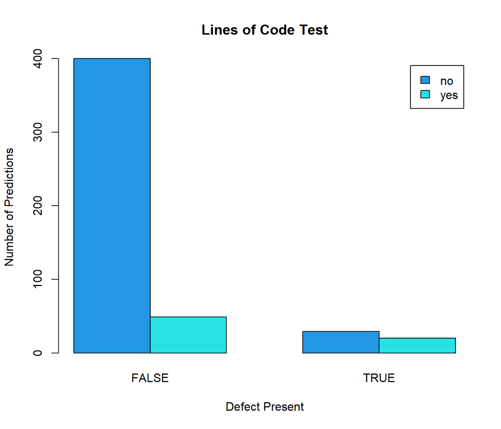

```r
barplot(loc.tab, beside=TRUE, leg=TRUE, col=4:5,
        ylab="Number of Predictions", xlab="Defect Present")
title(main= "Lines of Code Test")
```

Cyclomatic Complexity v Defect:

```r
#cyclomatic complexity v defect
cyclo.tab <- with(swdefects.tab, table(predict.vg.10, defect))

twowaysum(cyclo.tab, nrow(swdefects.tab))
```

```
##               No Defect Defect Row Totals
## Not Predicted       397     35        432
## Predicted            52     14         66
## Column Totals       449     49        498
```

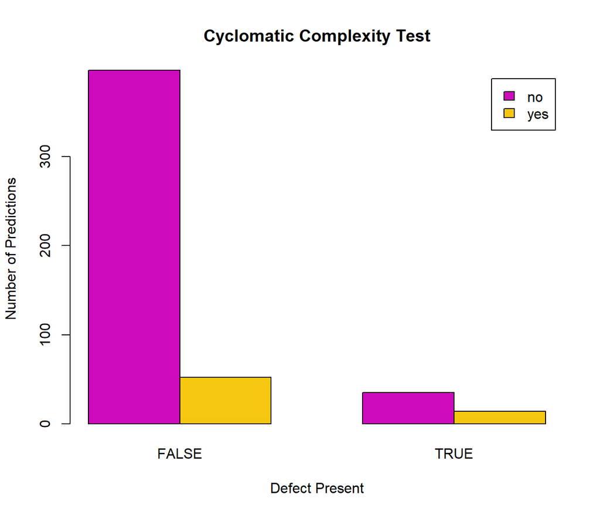

```r
barplot(cyclo.tab, beside=TRUE, leg=TRUE, col=6:7,
        ylab="Number of Predictions", xlab="Defect Present")
title(main="Cyclomatic Complexity Test")
```

Essential Complexity v Defect:

```r
#essential complexity v defect
evg.tab <- with(swdefects.tab, table(predict.evg.14.5, defect))

twowaysum(evg.tab, nrow(swdefects.tab))
```

```
##               No Defect Defect Row Totals
## Not Predicted       441     47        488
## Predicted             8      2         10
## Column Totals       449     49        498
```

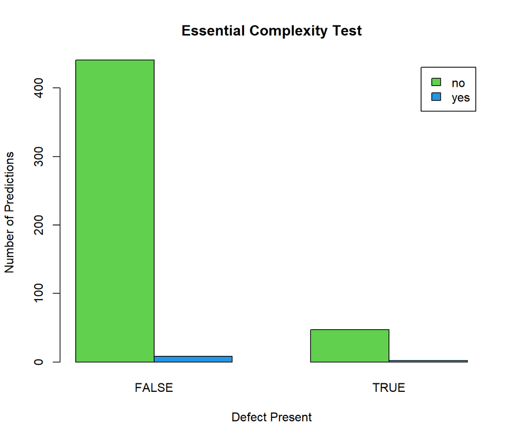

```r
barplot(evg.tab, beside=TRUE, leg=TRUE, col=11:12,
        ylab="Number of Predictions", xlab="Defect Present")
title(main="Essential Complexity Test")
```

Design Complexity v Defect:

```r
#design complexity v defect
ivg.tab <- with(swdefects.tab, table(predict.ivg.9.2, defect))

twowaysum(ivg.tab, nrow(swdefects.tab))
```

```
##               No Defect Defect Row Totals
## Not Predicted       422     38        460
## Predicted            27     11         38
## Column Totals       449     49        498
```

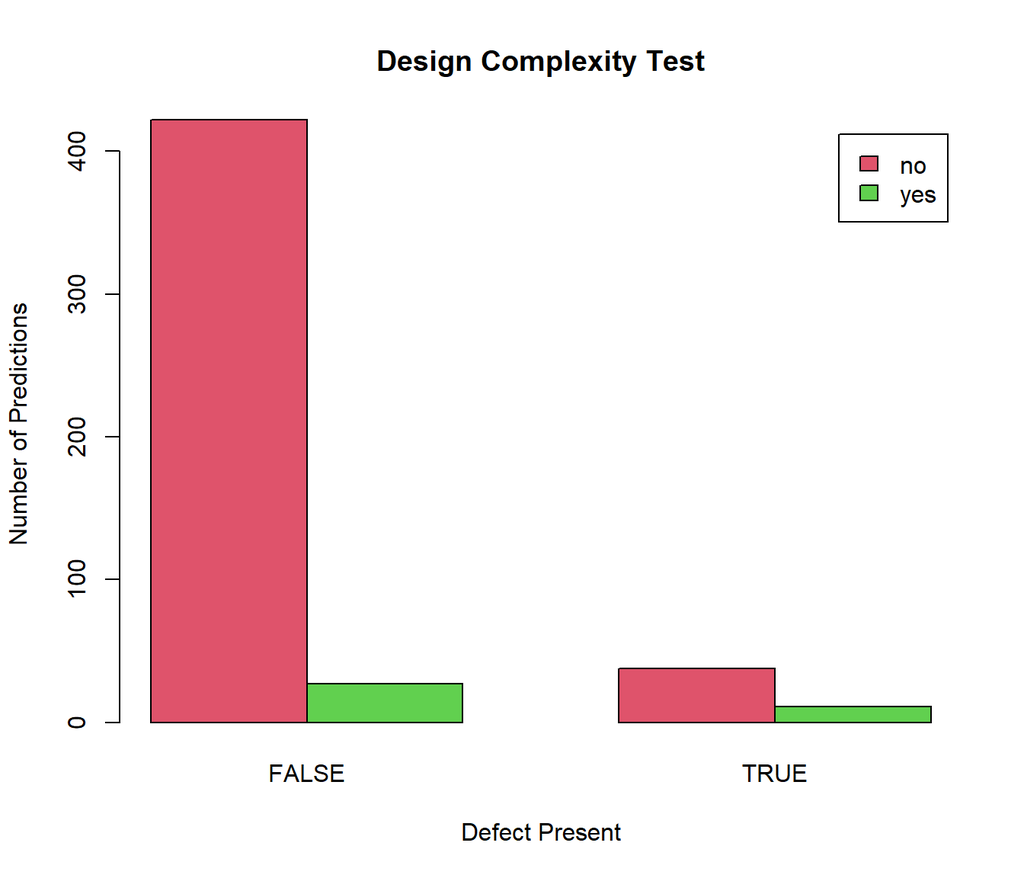

```r
barplot(ivg.tab, beside=TRUE, leg=TRUE, col=2:3,
        ylab="Number of Predictions", xlab="Defect Present")
title(main="Design Complexity Test")
```

# 4 Table and Barplot

## 4.1 Table Page 127

```r
#function to calculate accuracy, detection rate,
#false alarm rate, precision
prob_measure=function(summary.tab)
{
  a=summary.tab[1,1]
  b=summary.tab[1,2]
  c=summary.tab[2,1]
  d=summary.tab[2,2]

  accuracy=acc(a, b, c, d)
  accuracy=round(accuracy, 3)
  detection=detect(b, d)
  detection=round(detection,3)
  false_alarm=falarm(a, c)
  false_alarm=round(false_alarm, 3)
  precision=prec(c, d)
  precision=round(precision, 3)

  as.list(c(accuracy, detection, false_alarm, precision))
}

##collect measures and add title for gt
loc_measures <- c("Lines of Code", prob_measure(loc.tab))
cyclo_measures <-c("Cyclomatic Complexity", prob_measure(cyclo.tab))
ivg_measures <- c("Design Complexity", prob_measure(ivg.tab))
evg_measures <- c("Essential Complexity",prob_measure(evg.tab))

#table to store all values
measures <- matrix(c(loc_measures, cyclo_measures,                         evg_measures, ivg_measures)
                   ,nrow=4, ncol=5, byrow=TRUE)

##library I found online for making prettier tables
library(gt)
measures <- as.data.frame(measures)
gt_tbl <- gt(data=measures)

gt_tbl <-

  gt_tbl %>%
  tab_header(
    title="Probability Measures for Evaluating Defect
    Prediction Algorithms",
  ) %>%
  cols_label(
    V1="Method",
    V2="Accuracy", V3="Detection Rate",
    V4="False Alarm Rate", V5="Precision"
  )
gt_tbl
```

Probability Measures for Evaluating Defect Prediction Algorithms

| Method | Accuracy | Detection Rate | False Alarm Rate | Precision |
| --- | --- | --- | --- | --- |
| Lines of Code | 0.843 | 0.408 | 0.109 | 0.29 |
| Cyclomatic Complexity | 0.825 | 0.286 | 0.116 | 0.212 |
| Essential Complexity | 0.89 | 0.041 | 0.018 | 0.2 |
| Design Complexity | 0.869 | 0.224 | 0.06 | 0.289 |

## 4.2 Barplot of Data

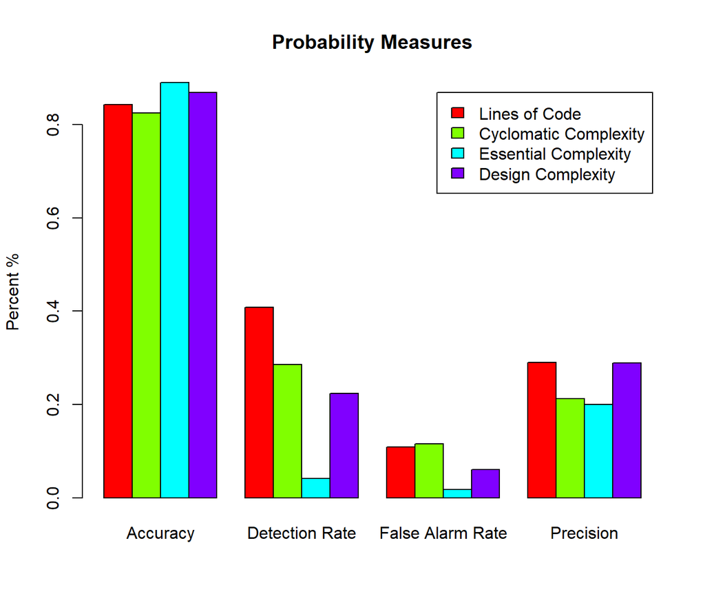

[output not shown]

```r
mybar=function(tab, accuracy){

  bar.plot <- barplot(tab, main="Probability Measures"
                  , ylab="Percent %"
                  ,legend = rownames(tab)
                  ,beside=TRUE, col=rainbow(4))

  bar.plot

  #return list
  as.list(tab)
}

#lists of measures for each test
loc_measures <-  prob_measure(loc.tab)
cyclo_measures <- prob_measure(cyclo.tab)
ivg_measures <- prob_measure(ivg.tab)
evg_measures <-  prob_measure(evg.tab)

#names for rows in table
rows <- c("Lines of Code", "Cyclomatic Complexity"
           ,"Essential Complexity", "Design Complexity")

#names for columns in table
cols <- c("Accuracy", "Detection Rate", "False Alarm Rate", "Precision")

#combine measurement lists into a table
measures.tab <- matrix(c(loc_measures, cyclo_measures
                         ,evg_measures, ivg_measures)
                       ,nrow=4,ncol=4, byrow=TRUE)

mode(measures.tab) = "numeric"
measures.tab <- as.table(measures.tab)

#assign names
colnames(measures.tab) <- cols
row.names(measures.tab) <- rows

mybar(measures.tab, 3)
```